# Diamonds EDA

Devin McCormack

1/23/2018

## Diamonds EDA

This is an exploration of the diamonds dataset, which is embedded in the ggplot library.

```r
library(tidyverse)
summary(diamonds)
```

```
##      carat               cut        color        clarity
##  Min.   :0.2000   Fair     : 1610   D: 6775   SI1    :13065
##  1st Qu.:0.4000   Good     : 4906   E: 9797   VS2    :12258
##  Median :0.7000   Very Good:12082   F: 9542   SI2    : 9194
##  Mean   :0.7979   Premium  :13791   G:11292   VS1    : 8171
##  3rd Qu.:1.0400   Ideal    :21551   H: 8304   VVS2   : 5066
##  Max.   :5.0100                     I: 5422   VVS1   : 3655
##                                     J: 2808   (Other): 2531
##      depth           table           price             x
##  Min.   :43.00   Min.   :43.00   Min.   :  326   Min.   : 0.000
##  1st Qu.:61.00   1st Qu.:56.00   1st Qu.:  950   1st Qu.: 4.710
##  Median :61.80   Median :57.00   Median : 2401   Median : 5.700
##  Mean   :61.75   Mean   :57.46   Mean   : 3933   Mean   : 5.731
##  3rd Qu.:62.50   3rd Qu.:59.00   3rd Qu.: 5324   3rd Qu.: 6.540
##  Max.   :79.00   Max.   :95.00   Max.   :18823   Max.   :10.740
##
##        y                z
##  Min.   : 0.000   Min.   : 0.000
##  1st Qu.: 4.720   1st Qu.: 2.910
##  Median : 5.710   Median : 3.530
##  Mean   : 5.735   Mean   : 3.539
##  3rd Qu.: 6.540   3rd Qu.: 4.040
##  Max.   :58.900   Max.   :31.800
##
```

```r
length(diamonds$carat)
```

```
## [1] 53940
```

```r
length(diamonds)
```

```
## [1] 10
```

## Quiz 1:

there are 53940 observations of 10 variables. There are three ordered factors (cut, color, clarity) with the best color being “D”

## Quiz 2:

a price histogram

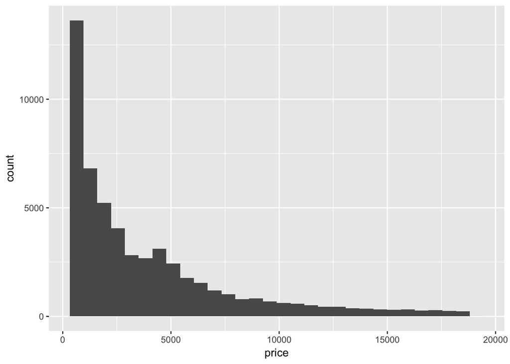

```r
ggplot(data=diamonds,aes(x=price))+
  geom_histogram()
```

## Quiz 3: describe the shape and center of the distribution

```r
mean(diamonds$price)
```

```
## [1] 3932.8
```

```r
median(diamonds$price)
```

```
## [1] 2401
```

The distribution has a long right tail with a mean of $3932.80 and a median of $2401.

## Quiz 4: Diamond counts

How many diamonds cost less than $500? How many diamonds cost less than $250? How many diamnods cost $15,000 or more?

```r
sum(diamonds$price<500)
```

```
## [1] 1729
```

```r
sum(diamonds$price<250)
```

```
## [1] 0
```

```r
sum(diamonds$price>=15000)
```

```
## [1] 1656
```

# Explore the largest peak in the price histogram you created earlier.

Try limiting the x-axis, altering the bin width, and setting different breaks on the x-axis.

There won’t be a solution video for this question so go to the discussions to share your thoughts and discover what other people find.

You can save images by using the ggsave() command. ggsave() will save the last plot created. For example… qplot(x = price, data = diamonds) ggsave(‘priceHistogram.png’)

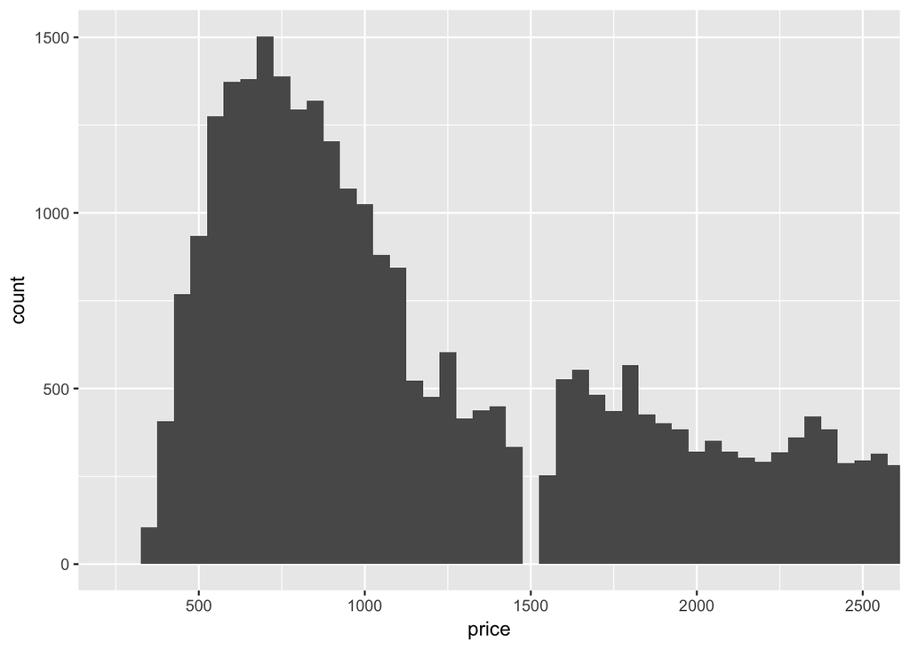

```r
ggplot(data=diamonds,aes(x=price))+
  geom_histogram(binwidth=50)+
  coord_cartesian(xlim=c(250,2500))
```

## Break out histograms by cut

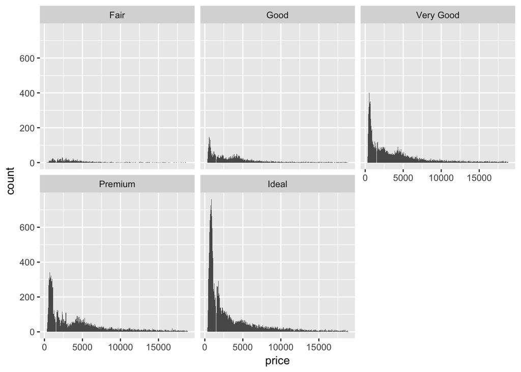

```r
ggplot(data=diamonds,aes(x=price))+
  geom_histogram(binwidth=50)+
  facet_wrap(~cut)
```

## Price by cut

Which has the highest priced diamond? Which has the lowest priced diamond? Which has the lowest median price?

```r
by(diamonds$price,diamonds$cut,max)
```

```
## diamonds$cut: Fair
## [1] 18574
## --------------------------------------------------------
## diamonds$cut: Good
## [1] 18788
## --------------------------------------------------------
## diamonds$cut: Very Good
## [1] 18818
## --------------------------------------------------------
## diamonds$cut: Premium
## [1] 18823
## --------------------------------------------------------
## diamonds$cut: Ideal
## [1] 18806
```

```r
by(diamonds$price,diamonds$cut,min)
```

```
## diamonds$cut: Fair
## [1] 337
## --------------------------------------------------------
## diamonds$cut: Good
## [1] 327
## --------------------------------------------------------
## diamonds$cut: Very Good
## [1] 336
## --------------------------------------------------------
## diamonds$cut: Premium
## [1] 326
## --------------------------------------------------------
## diamonds$cut: Ideal
## [1] 326
```

```r
by(diamonds$price,diamonds$cut,median)
```

```
## diamonds$cut: Fair
## [1] 3282
## --------------------------------------------------------
## diamonds$cut: Good
## [1] 3050.5
## --------------------------------------------------------
## diamonds$cut: Very Good
## [1] 2648
## --------------------------------------------------------
## diamonds$cut: Premium
## [1] 3185
## --------------------------------------------------------
## diamonds$cut: Ideal
## [1] 1810
```

Which has the highest priced diamond? premium Which has the lowest priced diamond? Premium and Ideal Which has the lowest median price? Ideal

## Scales for multiple histograms

In the last exercise, we looked at the summary statistics for diamond price by cut. If we look at the output table, the the median and quartiles are reasonably close to each other.

This means the distributions should be somewhat similar, but the histograms we created don’t show that.

The ‘Fair’ and ‘Good’ diamonds appear to have different distributions compared to the better cut diamonds. They seem somewhat uniform on the left with long tails on the right.

Let’s look in to this more.

Look up the documentation for facet_wrap in R Studio. Then, scroll back up and add a parameter to facet_wrap so that the y-axis in the histograms is not fixed. You want the y-axis to be different for each histogram.

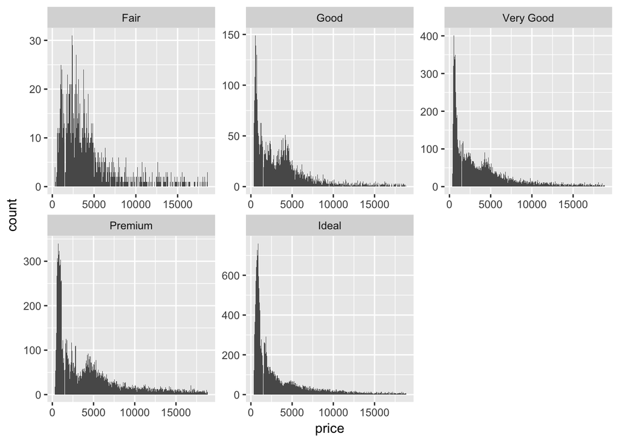

```r
ggplot(data=diamonds,aes(x=price))+
  geom_histogram(binwidth=50)+
  facet_wrap(~cut,scales='free')
```

# Two variables

## create histogram of price per carat faceted by cut

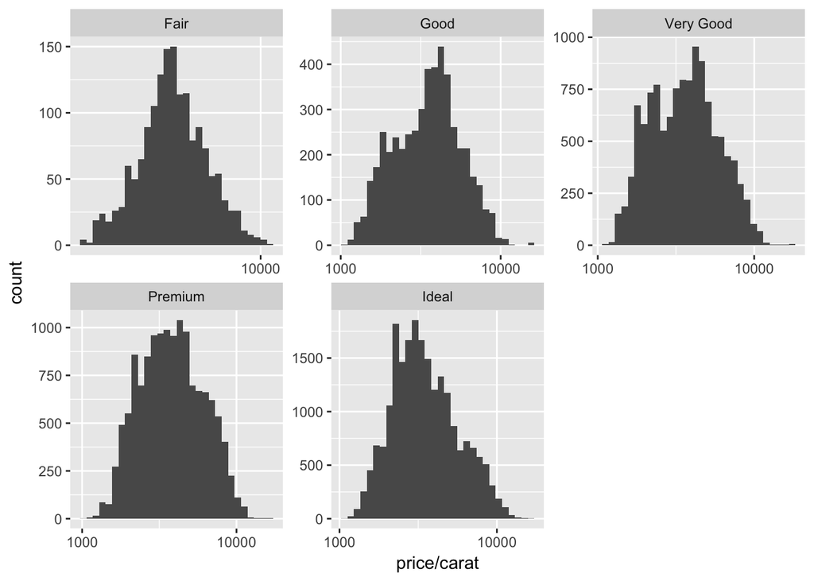

```r
ggplot(data=diamonds,aes(x=price/carat))+
  geom_histogram()+
  scale_x_log10()+
  facet_wrap(~cut,scales='free')
```